[figure not shown]

# Cooking in Dutch print, 1500–1940: a frame-oriented look

Every food mention in the corpus was annotated with a **frame**: what the text does with the food.

| frame | the food is … | frame elements kept here |
| --- | --- | --- |
| **COOKING_CREATION** | prepared | *Food_Product* (what is made), *Method* (how) |
| **INGESTION** | eaten or drunk |  |
| **CURE** | used as medicine | *Affliction*, *Food_Treatment* |
| **PRESERVING** | kept |  |

Questions: which frames dominate in which kinds of book and when; what is cooked and how; which foods move between the kitchen, the table and the apothecary; how the words for cooking change.

**Read before trusting a number**

- **The annotations are made by a language model** (with checks), not by hand. Frame elements are only kept when their words actually occur in the passage ("grounded"). Where the model gives a *Food_Product* or *Method*, about 9 and 8 in 10 are grounded; but only about **4 in 10 cooking mentions** end up with a usable product or method, so B–D describe that subset.
- **The corpus is a sample**, and uneven over time; **dates are edition years**; **genres** come from our own rules or, where those fail, from library catalogues (column `genre_source`).
- A mention counts once, whatever the quantity.

```python
import json
import re
from pathlib import Path

import matplotlib.pyplot as plt
import pandas as pd

# ✏️ Where the data is, RELATIVE TO THIS NOTEBOOK: "." = the same folder (as in the export).
DATA_SUBDIR = "."
DATA_DIR = Path(DATA_SUBDIR).resolve()   # Jupyter and VS Code run a notebook in its own folder
if not (DATA_DIR / "mentions.parquet").exists():
    raise FileNotFoundError(f"mentions.parquet is not in {DATA_DIR}. Put this notebook next to the export "
                            "(food_harvest folder), or set DATA_SUBDIR.")
m = pd.read_parquet(DATA_DIR / "mentions.parquet")
f = m[m["status"].eq("frame")].copy()
f["elements"] = f["frame_elements"].map(lambda s: json.loads(s) if isinstance(s, str) and s else {})
FRAMES = ["COOKING_CREATION", "INGESTION", "CURE", "PRESERVING"]
COLORS = {"COOKING_CREATION": "#e45756", "INGESTION": "#4c78a8", "CURE": "#54a24b", "PRESERVING": "#b279a2"}
print(f"📂 {DATA_DIR}\n{len(f):,} framed mentions in {f.work_id.nunique():,} works; with a year: {f.year.notna().mean():.0%}")
f["frame"].value_counts().to_frame("mentions")
```

```
📂 /Users/rikhoekstra/develop/Trifecta-event/food_frames/food_harvest
21,401 framed mentions in 2,397 works; with a year: 98%
```

| frame | mentions |
| --- | --- |
| COOKING_CREATION | 10135 |
| INGESTION | 7262 |
| CURE | 3514 |
| PRESERVING | 490 |

## A. Which frame, in which kind of book, and when

Share of each frame per genre (books with at least 100 framed mentions), and per 25 years.

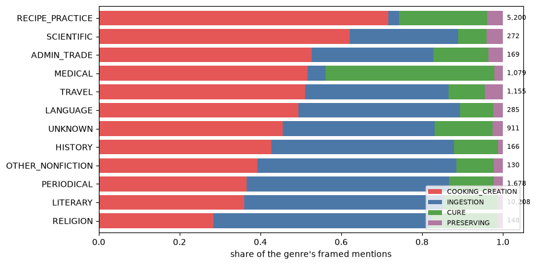

```python
g = pd.crosstab(f["genre"], f["frame"])[FRAMES]
g = g[g.sum(axis=1) >= 100]
share = g.div(g.sum(axis=1), axis=0).sort_values("COOKING_CREATION")
ax = share.plot.barh(stacked=True, figsize=(9, 4.5), color=[COLORS[c] for c in FRAMES], width=0.8)
ax.set_xlabel("share of the genre's framed mentions"); ax.set_ylabel(""); ax.legend(loc="lower right", fontsize=8)
for i, n in enumerate(g.loc[share.index].sum(axis=1)):
    ax.text(1.01, i, f"{n:,}", va="center", fontsize=8)
plt.tight_layout(); plt.show()
```

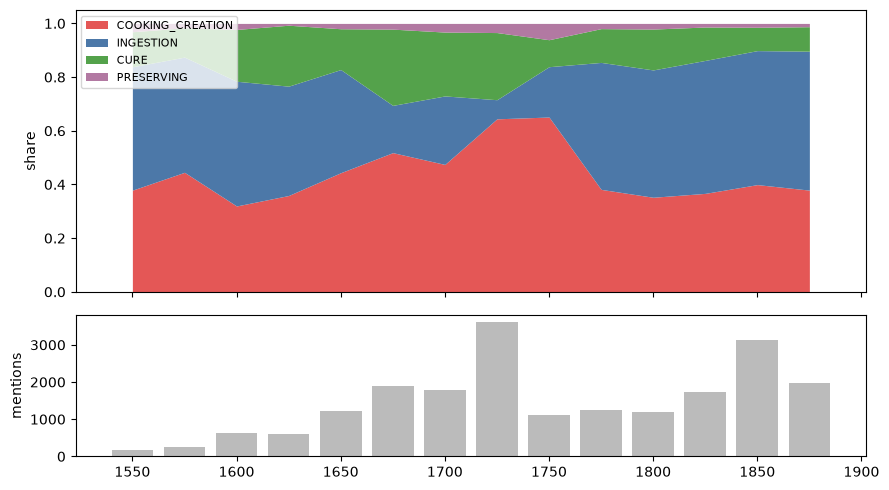

```python
t = f.dropna(subset=["year"]).assign(period=lambda d: (d.year // 25 * 25).astype(int))
t = pd.crosstab(t["period"], t["frame"])[FRAMES].loc[1550:1875]   # after 1900 too few mentions for a share
fig, (a1, a2) = plt.subplots(2, 1, figsize=(9, 5), sharex=True, gridspec_kw={"height_ratios": [2, 1]})
t.div(t.sum(axis=1), axis=0).plot.area(ax=a1, color=[COLORS[c] for c in FRAMES], linewidth=0)
a1.set_ylabel("share"); a1.legend(loc="upper left", fontsize=8); a1.set_xlabel("")
a2.bar(t.index, t.sum(axis=1), width=20, color="#bbbbbb")
a2.set_ylabel("mentions"); plt.tight_layout(); plt.show()
```

**Reading it.** Cookbooks (`RECIPE_PRACTICE`) are what you would expect: mostly cooking, with a solid share of **cure** (recipes for the sick, home remedies) and most of the **preserving**. Medical books are nearly all cure and cooking (preparing a remedy *is* cooking). Literary and periodical texts are about **eating and drinking**. Over time the share of cure falls, the share of ingestion rises: read with the counts below the chart, since the early periods are small.

## B. What is cooked

The *Food_Product* of the cooking frame: what the passage says is being made (grounded only).

```python
cook = f[f.frame == "COOKING_CREATION"].copy()
def grounded(row, key):
    v = row.elements.get(key)
    return v.lower() if isinstance(v, str) and v and v.lower() in str(row.context).lower() else None
cook["product"] = [grounded(r, "COOKING_CREATION_Food_Product") for r in cook.itertuples()]
cook["method_raw"] = [grounded(r, "COOKING_CREATION_Method") for r in cook.itertuples()]
print(f"cooking mentions: {len(cook):,}; with a grounded product: {cook['product'].notna().mean():.0%}, method: {cook['method_raw'].notna().mean():.0%}")
cook["product"].value_counts().head(30).to_frame("mentions").T
```

```
cooking mentions: 10,135; with a grounded product: 39%, method: 40%
```

| product | brood | vleesch | rijst | visch | wyn | wijn | vruchten | soep | bier | koeken | ... | spijs | pap | brandewijn | koek | siroop | ragout | meel | olie | haring | kool |
| --- | --- | --- | --- | --- | --- | --- | --- | --- | --- | --- | --- | --- | --- | --- | --- | --- | --- | --- | --- | --- | --- |
| mentions | 157 | 156 | 109 | 74 | 64 | 63 | 62 | 60 | 55 | 44 | ... | 31 | 30 | 29 | 28 | 27 | 26 | 26 | 25 | 22 | 20 |

1 rows × 30 columns

```python
PERIODS = [(1500, 1649), (1650, 1749), (1750, 1849), (1850, 1940)]   # note sambal after 1850: the Indies kitchen in print
cols = {}
for a, b in PERIODS:
    p = cook[cook.year.between(a, b)]["product"].value_counts()
    cols[f"{a}–{b}"] = (p.head(12).index + " (" + p.head(12).astype(str).values + ")").tolist()
pd.DataFrame({k: pd.Series(v) for k, v in cols.items()})
```

|  | 1500–1649 | 1650–1749 | 1750–1849 | 1850–1940 |
| --- | --- | --- | --- | --- |
| 0 | vleesch (22) | brood (48) | brood (57) | vleesch (50) |
| 1 | rijst (18) | vleesch (42) | rijst (45) | brood (46) |
| 2 | wijn (12) | syroop (32) | vleesch (40) | soep (42) |
| 3 | vis (7) | wyn (31) | wyn (27) | rijst (38) |
| 4 | vruchten (5) | wijn (29) | visch (27) | visch (30) |
| 5 | boonen (4) | melk (28) | koeken (22) | aardappelen (23) |
| 6 | vlees (4) | vlees (28) | vruchten (19) | vruchten (21) |
| 7 | vrucht (4) | vis (27) | soep (17) | sambal (17) |
| 8 | bier (4) | deeg (25) | bier (14) | bier (16) |
| 9 | broot (4) | siroop (24) | kaas (14) | taart (16) |
| 10 | wyn (3) | bier (21) | koek (12) | koeken (15) |
| 11 | visch (3) | pap (21) | brandewijn (11) | kaas (15) |

## C. How: the methods, and their words

The *Method* element, normalised to a verb (hand-made list below: *gekookt, kookt, kooken* → koken). The list is short on purpose; anything not on it stays `other`. Note **sieden / zieden** (*gesoden*): the older word for boiling.

```python
METHODS = [  # (verb, pattern on the Method words); first match wins
    ("sieden", r"\b(?:ge)?[sz](?:ie|ee)d|\bgesoden|\bzood"),
    ("koken", r"\b(?:ge|door)?k(?:oo|o)k"),
    ("braden", r"\b(?:ge)?braa?d|\bbraet"),
    ("bakken", r"\b(?:ge)?bac?kk?(?:en|t)?\b|\bgebacken"),
    ("stoven", r"\b(?:ge)?stoo?v"),
    ("roosteren", r"rooster"),
    ("smelten", r"smelt"),
    ("mengen", r"\b(?:ge)?meng"),
    ("stampen", r"stamp"),
    ("snijden", r"\b(?:ge)?sn(?:ij|y|e)d|\bsned"),
    ("weken", r"\b(?:ge)?wee?k(?:en|t)\b"),
    ("trekken", r"\btrek|\bgetrokken"),
    ("distilleren", r"distill|distil"),
    ("branden", r"\b(?:ge)?brand"),
    ("brouwen", r"brouw"),
]
def verb(s):
    if not isinstance(s, str):
        return None
    for v, p in METHODS:
        if re.search(p, s):
            return v
    return "other"
cook["method"] = cook["method_raw"].map(verb)
cook["method"].value_counts().to_frame("mentions").T
```

| method | other | koken | mengen | braden | bakken | stampen | snijden | sieden | smelten | distilleren | trekken | branden | stoven | weken | roosteren | brouwen |
| --- | --- | --- | --- | --- | --- | --- | --- | --- | --- | --- | --- | --- | --- | --- | --- | --- |
| mentions | 2059 | 592 | 328 | 231 | 185 | 106 | 100 | 98 | 88 | 68 | 63 | 47 | 28 | 27 | 8 | 5 |

```python
# what the verb list does not cover yet: extend METHODS above with what you see here
cook.loc[cook.method == "other", "method_raw"].value_counts().head(30).to_frame("mentions").T
```

| method_raw | doet | gesmolten | bereiden | steken | giet | gedaan | doen | ragout | verkoken | steekt | ... | stoot | maken | persen | gegoten | broot | voeden | spek in de pan | zouten | gieten | pelde garst |
| --- | --- | --- | --- | --- | --- | --- | --- | --- | --- | --- | --- | --- | --- | --- | --- | --- | --- | --- | --- | --- | --- |
| mentions | 30 | 17 | 15 | 11 | 10 | 10 | 10 | 9 | 8 | 8 | ... | 6 | 6 | 6 | 6 | 6 | 6 | 6 | 6 | 5 | 5 |

1 rows × 30 columns

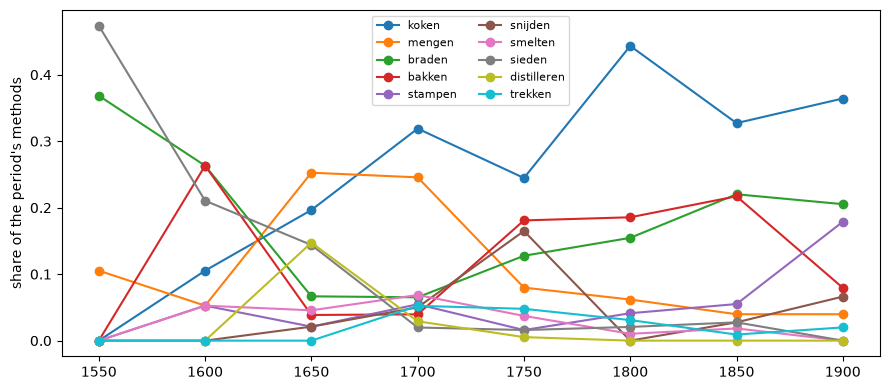

| period method | 1550 | 1600 | 1650 | 1700 | 1750 | 1800 | 1850 | 1900 |
| --- | --- | --- | --- | --- | --- | --- | --- | --- |
| koken | 0 | 2 | 56 | 274 | 46 | 43 | 107 | 55 |
| mengen | 2 | 1 | 72 | 211 | 15 | 6 | 13 | 6 |
| braden | 7 | 5 | 19 | 56 | 24 | 15 | 72 | 31 |
| bakken | 0 | 5 | 11 | 34 | 34 | 18 | 71 | 12 |
| stampen | 0 | 1 | 6 | 47 | 3 | 4 | 18 | 27 |
| snijden | 0 | 0 | 6 | 43 | 31 | 0 | 9 | 10 |
| smelten | 0 | 1 | 13 | 59 | 7 | 1 | 6 | 0 |
| sieden | 9 | 4 | 41 | 17 | 3 | 2 | 9 | 0 |
| distilleren | 0 | 0 | 42 | 25 | 1 | 0 | 0 | 0 |
| trekken | 0 | 0 | 0 | 45 | 9 | 3 | 3 | 3 |

```python
mt = cook.dropna(subset=["method", "year"]).query("method != 'other'").assign(period=lambda d: (d.year // 50 * 50).astype(int))
mt = pd.crosstab(mt["method"], mt["period"]).loc[:, 1550:1900]
show = mt.sum(axis=1).sort_values(ascending=False).index[:10]
ax = mt.loc[show].div(mt.sum(axis=0), axis=1).T.plot(marker="o", figsize=(9, 4))
ax.set_ylabel("share of the period's methods"); ax.set_xlabel(""); ax.legend(ncol=2, fontsize=8); plt.tight_layout(); plt.show()
mt.loc[show]
```

**Reading it.** **Sieden** is the main boiling word of the earliest books (most of the few methods before 1600, 41 in 1650–1699) and fades as **koken** takes over (274 in 1700–1749): the same act, a new word. *Braden* and *bakken* are there throughout; *distilleren* and *trekken* (infusing) cluster in 1650–1749, the age of household remedies in recipe form. Mind the counts: the periods before 1650 are small.

## D. Which foods, which methods

For the foods most often cooked (the annotated food word, `pref_label`): how they are prepared.

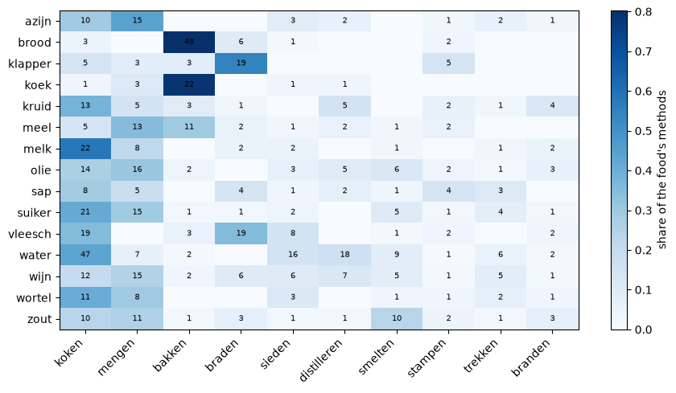

```python
fm = cook.dropna(subset=["method"]).query("method != 'other'")
top_food = fm["pref_label"].value_counts().head(15).index
x = pd.crosstab(fm.loc[fm.pref_label.isin(top_food), "pref_label"], fm.loc[fm.pref_label.isin(top_food), "method"])
x = x[x.sum().sort_values(ascending=False).index[:10]]
fig, ax = plt.subplots(figsize=(9, 5))
im = ax.imshow(x.div(x.sum(axis=1), axis=0).values, cmap="Blues", aspect="auto")
ax.set_xticks(range(x.shape[1]), x.columns, rotation=45, ha="right"); ax.set_yticks(range(x.shape[0]), x.index)
for (i, j), v in pd.DataFrame(x.values).stack().items():
    if v: ax.text(j, i, v, ha="center", va="center", fontsize=7)
fig.colorbar(im, ax=ax, label="share of the food's methods"); plt.tight_layout(); plt.show()
```

## E. Between kitchen, table and apothecary

For one food at a time: the share of each frame per period. Change `FOOD` (the `pref_label`, e.g. *suiker*, *thee*, *koffie*, *kaneel*, *peper*, *wijn*, *azijn*, *honing*).

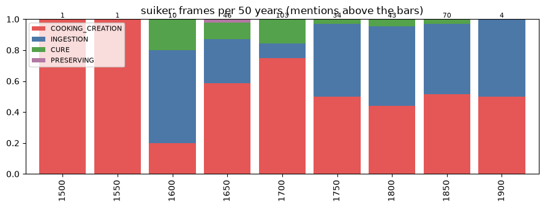

```python
FOOD = "suiker"
one = f[(f.pref_label == FOOD) & f.year.notna()].assign(period=lambda d: (d.year // 50 * 50).astype(int))
ft = pd.crosstab(one["period"], one["frame"]).reindex(columns=FRAMES, fill_value=0)
ax = ft.div(ft.sum(axis=1), axis=0).plot.bar(stacked=True, color=[COLORS[c] for c in FRAMES], figsize=(9, 3.5), width=0.85)
ax.set_title(f"{FOOD}: frames per 50 years (mentions above the bars)"); ax.set_xlabel(""); ax.legend(fontsize=8, loc="upper left")
for i, n in enumerate(ft.sum(axis=1)):
    ax.text(i, 1.01, n, ha="center", fontsize=8)
plt.tight_layout(); plt.show()
```

```python
# all foods at once: which ones shift most from cure to cooking or eating (foods with 40+ dated mentions)
dated = f.dropna(subset=["year"])
early, late = dated[dated.year < 1700], dated[dated.year >= 1750]
rows = []
for food, n in dated["pref_label"].value_counts().items():
    if n < 40:
        break
    e, l = early[early.pref_label == food], late[late.pref_label == food]
    if len(e) >= 10 and len(l) >= 10:
        rows.append({"food": food, "mentions": n, "cure before 1700": (e.frame == "CURE").mean(), "cure after 1750": (l.frame == "CURE").mean()})
shift = pd.DataFrame(rows).assign(change=lambda d: d["cure after 1750"] - d["cure before 1700"]).sort_values("change")
shift.round(2).head(12)
```

|  | food | mentions | cure before 1700 | cure after 1750 | change |
| --- | --- | --- | --- | --- | --- |
| 56 | noot | 58 | 0.36 | 0.05 | -0.32 |
| 41 | olijf | 80 | 0.30 | 0.00 | -0.30 |
| 13 | thee | 351 | 0.33 | 0.06 | -0.27 |
| 10 | zout | 404 | 0.33 | 0.08 | -0.25 |
| 38 | citroen | 87 | 0.23 | 0.00 | -0.23 |
| 17 | brandewijn | 247 | 0.37 | 0.15 | -0.22 |
| 22 | koek | 190 | 0.25 | 0.03 | -0.22 |
| 18 | sap | 239 | 0.36 | 0.15 | -0.21 |
| 59 | kruidnagel | 57 | 0.20 | 0.00 | -0.20 |
| 8 | melk | 459 | 0.29 | 0.09 | -0.19 |
| 20 | rijs | 209 | 0.22 | 0.04 | -0.18 |
| 53 | os | 61 | 0.22 | 0.04 | -0.18 |

## F. Read the passages

The passages behind any number: choose a food, a frame or a method.

```python
FOOD, FRAME, METHOD = "suiker", "COOKING_CREATION", None   # METHOD e.g. "sieden"
r = cook if METHOD else f
r = r[(r.pref_label == FOOD) & (r.frame == FRAME)]
if METHOD:
    r = r[r.method == METHOD]
for x in r.sort_values("year").head(12).itertuples():
    print(f"{x.year}  {x.genre:16} {x.title[:40]:40}  …{str(x.context)[:170]}…")
```

```
1544  TRAVEL           Die ridderlycke reyse van heer Lodewijck  …y vleesch sonder allee n coeyen vleesch en de si eten op der eerden op cleederen, oft tapecerije wt houten schotele n , mer seer schoon. Haren dranc is water en de suycke…
1596  LITERARY         Cort verhael van tPrincipael, in Leyden   …n op snaren, met clapspanen geluyt: Elc Sot zijn blaes brengt mee, coe m t met de hantpijp uyt Om houbollich en ruyt// te danssen, springen, spelen, Daer Mommers wel gemu…
1612  HISTORY          Chroniicke vande Hertoghen van Brabant    …ende dat van honich ende water. Oock noch anderen dranck van ghestooten appelen oft peeren, daer t'sap wt geperst wort, den welcken alsoo met suycker gemengt, ghewoonlijc…
1649  LITERARY         't Kleyn lust-hofje vol van bruyloft-zan  …ry de keurigst keuren, Hier zijn by een gestelt van alderhande slag, Van velerleye toon, van hoog en laag gezag, Zom ernstig, zom wat boers, dog geen om vreugt te steuren…
1669  LITERARY         Theatrum stultorum                        …blickt den Dagheraet, Met haer blosende ghelaet: Oft sy moeten uyt hunn' pluymen, En hunn' warme nesten ruymen, Met hunn' billen noch half bloodt, Voor hunn' voghels wyke…
1670  LITERARY         d'Uytgelesenste Wonderen, en bysonderste  …n, en voor Wijn gebruycke n . Dit geschied in d'eerste drie dagen na de snoeying des Booms. Drie dage n daar na werd dit Water van zig selve n Edik: Doch die'er Suycker v…
1671  TRAVEL           Verhaal van drie voorname reizen naar Oo  …half water, en half brandewijn gemakt, daar zy dartig of veertig limoenen zonder korrelen, en een weinig suiker in doen. Deze drank is niet zo aangenaam van smaak, en ook…
1678  LITERARY         Sedelycke lust-warande                    …t aen gheraecken sonder te climmen, en u te clemmen, dat is sonder u reputatie te buyten te gaen, sonder eenen quaeden naem te crijghen, sonder duysent injuries voor suyc…
1678  LITERARY         Den Goddelycken Minnenpijl                …bidt hem te gader, Met blij gheschal. 9. Phylis. K’waer blij dat ick had me ghenomen, Mijn Moeselken, Om te vereeren ben ick ghekomen, Dit Kindeken, Wy bringhen Melck om …
1678  LITERARY         Den Goddelycken Minnenpijl                …m te gader, Met blij gheschal. 9. Phylis. K’waer blij dat ick had me ghenomen, Mijn Moeselken, Om te vereeren ben ick ghekomen, Dit Kindeken, Wy bringhen Melck om papken …
1683  MEDICAL          Pharmacopaea Amstelredamensis, of d' Ams  …versch ana unc. quatuor. Klein gestoten zijnde, kooktse te samen in een goed deel regenwater, laatse een nagt weiken, warm doorgesegen zijnde, mengt daar by vier pond wit…
1683  MEDICAL          Pharmacopaea Amstelredamensis, of d' Ams  …gesneden en gestooten zijnde, laatse met elkander vier en twintig uuren weiken, laat het dan eens sagjes opkoken, giet het kooksel door een seef, doet daar vijf pond witt…
```

## Where to go from here

- **Ingredients together**: which foods are cooked *with* which (the passages name several): co-occurrence as in the term-relations notebook.
- **Recipes as units**: a passage is ~600 characters; a recipe is the natural unit, and the cookbooks' structure (titles, recipe headings) would give it.
- **Trade and table**: the kg_mockup notebooks show when coffee, tea and sugar arrive in the Republic; here you can see when they move from the apothecary to the kitchen.

[figure not shown]